# Neo4j_Habsburg_Presentation

**Neo4j + Python Case Study: The Habsburgs**  
Prepared by Natalia Zelenko, powered by the beauty of graphs, 2025

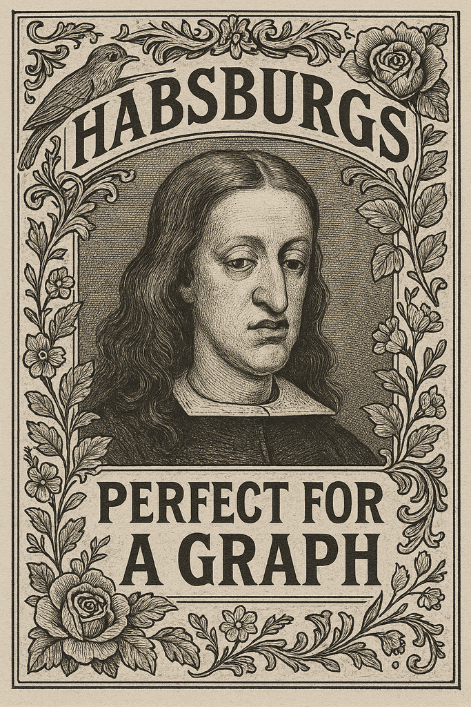

Generated by Sora with a custom prompt.

```python
from neo4j import GraphDatabase
import pandas as pd
from IPython.display import display, HTML
```

Let's connect to Neo4j!

```python
uri = "bolt://localhost:7687"
user = "neo4j"
password = "recursiveroyalty"

driver = GraphDatabase.driver(uri, auth=(user, password))
```

Now let's run a query to test the connection.

```python
with driver.session() as session:
    session.execute_read(
        lambda tx: (
            [print(record["message"]) for record in tx.run("RETURN 'Neo4j says hi!' AS message")]
        )
    )
```

```
Neo4j says hi!
```

It worked! Now, what do we have here? Our little Habsburg cluster.

```python
df_people = pd.read_csv("data/HABS_people.csv")
display(HTML(df_people.to_html()))
```

|  | person_id | name | born | died | gender | house |
| --- | --- | --- | --- | --- | --- | --- |
| 0 | 1 | Charles II of Spain | 1661 | 1700 | M | Habsburg |
| 1 | 2 | Marie Louise d'Orléans | 1662 | 1689 | F | Orléans |
| 2 | 3 | Maria Anna of Neuburg | 1667 | 1740 | F | Wittelsbach |
| 3 | 4 | Philip IV of Spain | 1605 | 1665 | M | Habsburg |
| 4 | 5 | Mariana of Austria | 1634 | 1696 | F | Habsburg |
| 5 | 6 | Margaret Theresa of Spain | 1651 | 1673 | F | Habsburg |
| 6 | 7 | Leopold I, Holy Roman Emperor | 1640 | 1705 | M | Habsburg |
| 7 | 8 | Ferdinand III, Holy Roman Emperor | 1608 | 1657 | M | Habsburg |
| 8 | 9 | Maria Anna of Spain | 1606 | 1646 | F | Habsburg |
| 9 | 10 | Philip III of Spain | 1578 | 1621 | M | Habsburg |
| 10 | 11 | Margaret of Austria | 1584 | 1611 | F | Habsburg |
| 11 | 12 | Philip II of Spain | 1527 | 1598 | M | Habsburg |
| 12 | 13 | Anna of Austria | 1549 | 1580 | F | Habsburg |
| 13 | 14 | Charles II Francis of Austria | 1540 | 1590 | M | Habsburg |
| 14 | 15 | Maria Anna of Bavaria | 1551 | 1608 | F | Wittelsbach |
| 15 | 16 | Ferdinand II, Holy Roman Emperor | 1578 | 1637 | M | Habsburg |
| 16 | 17 | Maria Anna of Bavaria | 1574 | 1616 | F | Wittelsbach |
| 17 | 18 | Charles V, Holy Roman Emperor | 1500 | 1558 | M | Habsburg |
| 18 | 19 | Isabella of Portugal | 1503 | 1539 | F | Aviz |
| 19 | 20 | Maria of Spain | 1528 | 1603 | F | Habsburg |
| 20 | 21 | Maximilian II, Holy Roman Emperor | 1527 | 1576 | M | Habsburg |
| 21 | 22 | Ferdinand I, Holy Roman Emperor | 1503 | 1564 | M | Habsburg |
| 22 | 23 | Anne of Bohemia and Hungary | 1503 | 1547 | F | Jagiellon |
| 23 | 24 | Philip the Handsome | 1478 | 1506 | M | Habsburg |
| 24 | 25 | Joanna of Castile | 1479 | 1555 | F | Trastámara |

Some of them are married.

```python
df_marriage = pd.read_csv("data/HABS_marriage.csv")
display(HTML(df_marriage.to_html()))
```

|  | husband_id | wife_id | year |
| --- | --- | --- | --- |
| 0 | 1 | 2 | 1679 |
| 1 | 1 | 3 | 1689 |
| 2 | 4 | 5 | 1649 |
| 3 | 7 | 6 | 1666 |
| 4 | 8 | 9 | 1631 |
| 5 | 10 | 11 | 1599 |
| 6 | 12 | 13 | 1570 |
| 7 | 14 | 15 | 1571 |
| 8 | 16 | 17 | 1600 |
| 9 | 18 | 19 | 1526 |
| 10 | 21 | 20 | 1548 |
| 11 | 22 | 23 | 1521 |
| 12 | 24 | 25 | 1496 |

Some — related by blood.

```python
df_blood = pd.read_csv("data/HABS_blood.csv")
display(HTML(df_blood.to_html()))
```

|  | person1_id | person2_id | person1_role | person2_role |
| --- | --- | --- | --- | --- |
| 0 | 4 | 5 | uncle | niece |
| 1 | 4 | 5 | first cousin once removed | first cousin once removed |
| 2 | 4 | 5 | second cousin once removed | second cousin once removed |
| 3 | 4 | 1 | father | son |
| 4 | 5 | 1 | mother | son |
| 5 | 4 | 1 | great uncle | grand-nephew |
| 6 | 5 | 1 | cousin | cousin |
| 7 | 4 | 6 | father | daughter |
| 8 | 5 | 6 | mother | daughter |
| 9 | 4 | 6 | great uncle | grand-niece |
| 10 | 5 | 6 | cousin | cousin |
| 11 | 7 | 6 | uncle | niece |
| 12 | 7 | 6 | cousin | cousin |
| 13 | 7 | 6 | second cousin once removed | second cousin once removed |
| 14 | 8 | 9 | cousin | cousin |
| 15 | 8 | 9 | second cousin | second cousin |
| 16 | 9 | 5 | mother | daughter |
| 17 | 8 | 5 | father | daughter |
| 18 | 8 | 7 | father | son |
| 19 | 9 | 7 | mother | son |
| 20 | 10 | 9 | father | daughter |
| 21 | 11 | 9 | mother | daughter |
| 22 | 10 | 4 | father | son |
| 23 | 11 | 4 | mother | son |
| 24 | 12 | 10 | father | son |
| 25 | 13 | 10 | mother | son |
| 26 | 14 | 11 | father | daughter |
| 27 | 15 | 11 | mother | daughter |
| 28 | 14 | 16 | father | son |
| 29 | 15 | 16 | mother | son |
| 30 | 16 | 8 | father | son |
| 31 | 17 | 8 | mother | son |
| 32 | 15 | 17 | aunt | niece |
| 33 | 16 | 17 | cousin | cousin |
| 34 | 18 | 12 | father | son |
| 35 | 19 | 12 | mother | son |
| 36 | 18 | 20 | father | daughter |
| 37 | 19 | 20 | mother | daughter |
| 38 | 21 | 13 | father | daughter |
| 39 | 20 | 13 | mother | daughter |
| 40 | 22 | 21 | father | son |
| 41 | 23 | 21 | mother | son |
| 42 | 22 | 14 | father | son |
| 43 | 23 | 14 | mother | son |
| 44 | 24 | 18 | father | son |
| 45 | 25 | 18 | mother | son |
| 46 | 24 | 22 | father | son |
| 47 | 25 | 22 | mother | son |
| 48 | 20 | 21 | cousin | cousin |
| 49 | 12 | 13 | uncle | niece |
| 50 | 12 | 13 | first cousin once removed | first cousin once removed |
| 51 | 12 | 13 | second cousin | second cousin |
| 52 | 10 | 11 | first cousin once removed | first cousin once removed |
| 53 | 10 | 11 | second cousin | second cousin |
| 54 | 9 | 7 | first cousin once removed | first cousin once removed |
| 55 | 9 | 11 | first cousin once removed | first cousin once removed |
| 56 | 4 | 11 | first cousin once removed | first cousin once removed |
| 57 | 11 | 15 | first cousin once removed | first cousin once removed |
| 58 | 16 | 15 | first cousin once removed | first cousin once removed |
| 59 | 12 | 10 | great uncle | grand-nephew |
| 60 | 13 | 10 | cousin | cousin |
| 61 | 13 | 20 | first cousin once removed | first cousin once removed |

Wait. 25 people, 13 marriages and *HOW MANY* blood relationships?  
What kind of a family tree spider web is this?

[figure not shown]

Generated by Sora with a custom prompt.

This function will help us create a Neo4j node from one row of our df_people DataFrame.

```python
def create_person_node(tx, person_id, name, born, died, gender, house):
    query = """
    MERGE (p:Person {person_id: $person_id})
    ON CREATE SET
        p.name = $name,
        p.born = $born,
        p.died = $died,
        p.gender = $gender,
        p.house = $house
        RETURN CASE WHEN p.name IS NOT NULL THEN 1 ELSE 0 END AS processed_flag
    """
    result = tx.run(query, person_id=person_id, name=name, born=born, died=died, gender=gender, house=house)
    record = result.single()
    return record["processed_flag"] if record else 0
```

Now let's use it.

```python
total_processed = 0
with driver.session() as session:
    for _, row in df_people.iterrows():
        processed = session.execute_write(
            create_person_node,
            int(row['person_id']),
            row['name'],
            int(row['born']) if not pd.isna(row['born']) else None,
            int(row['died']) if not pd.isna(row['died']) else None,
            row['gender'],
            row['house']
        )
        total_processed += processed

print(f"Total Person nodes processed: {total_processed}")
```

```
Total Person nodes processed: 25
```

Here they are, lonely unconnected nodes. Note that the orange ones are all Habsburgs.

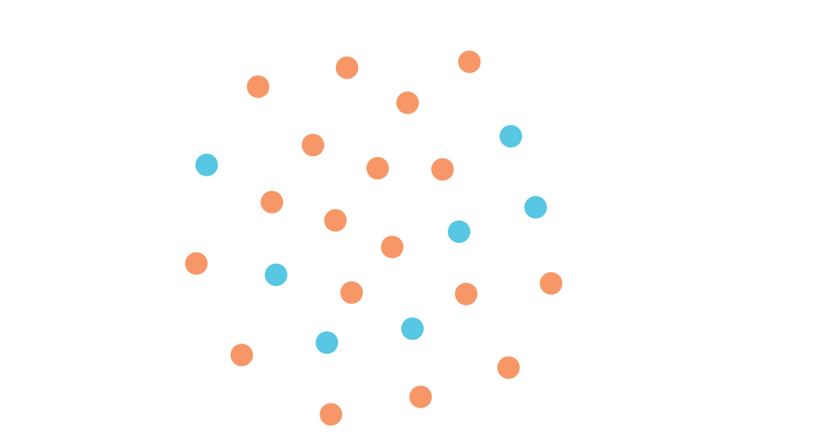

screenshot from Neo4j Bloom

And here's everyone's favourite Habsburg.

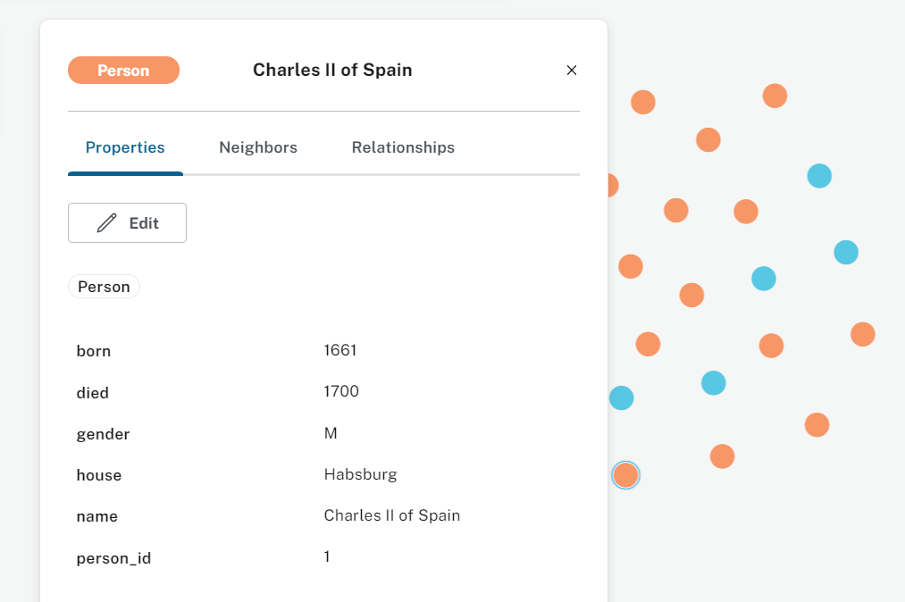

screenshot from Neo4j Bloom

Now let's define a similar function to create the bonds of matrimony, and then use it.

```python
def create_marriage_relationship(tx, husband_id, wife_id, year):
    query = """
    MATCH (h:Person {person_id: $husband_id})
    MATCH (w:Person {person_id: $wife_id})
    MERGE (h)-[r:MARRIED_TO]->(w)
    ON CREATE SET r.year = $year
    RETURN CASE WHEN r.year IS NOT NULL THEN 1 ELSE 0 END AS processed_flag
    """
    result = tx.run(query, husband_id=husband_id, wife_id=wife_id, year=year)
    record = result.single()
    return record["processed_flag"] if record else 0
```

```python
total_processed = 0
with driver.session() as session:
    for _, row in df_marriage.iterrows():
        processed = session.execute_write(
            create_marriage_relationship,
            int(row['husband_id']),
            int(row['wife_id']),
            int(row['year'])
        )
        total_processed += processed

print(f"Total MARRIED_TO relationships processed: {total_processed}")
```

```
Total MARRIED_TO relationships processed: 13
```

Now, every one's coupled up nicely.

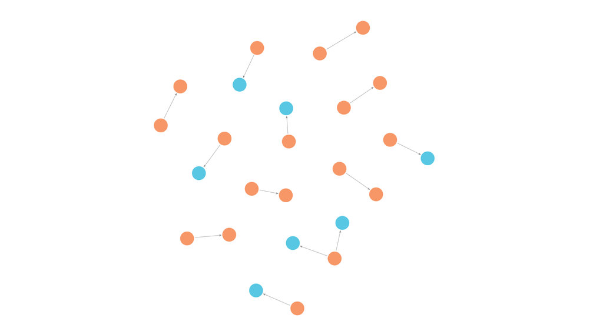

screenshot from Neo4j Bloom

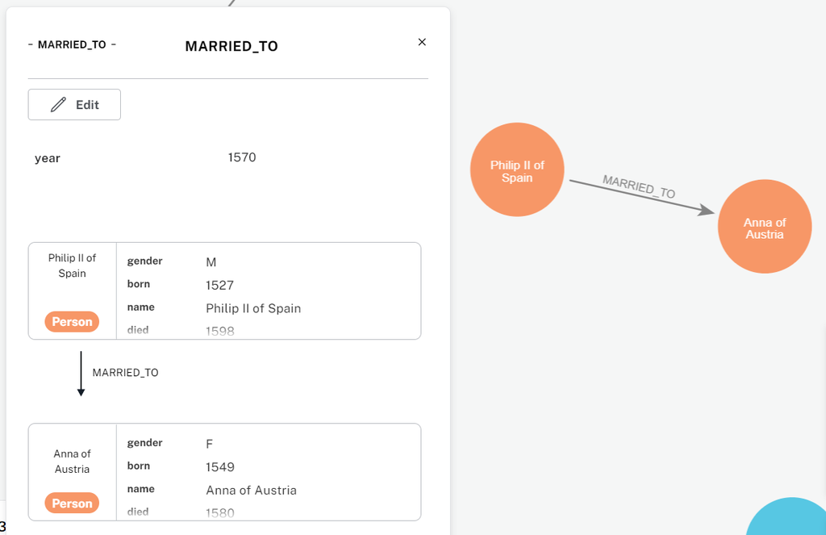

screenshot from Neo4j Bloom

Ready or not, here they come! The blood relationships.

```python
def create_blood_relationship(tx, person1_id, person2_id, person1_role, person2_role):
    rel_type = person1_role.strip().upper().replace(" ", "_").replace("-", "_")

    query = f"""
    MATCH (p1:Person {{person_id: $person1_id}})
    MATCH (p2:Person {{person_id: $person2_id}})
    MERGE (p1)-[r:{rel_type}]->(p2)
    ON CREATE SET r.to_role = $person2_role
    RETURN CASE WHEN r.to_role IS NOT NULL THEN 1 ELSE 0 END AS processed_flag
    """
    result = tx.run(query, person1_id=person1_id, person2_id=person2_id, person2_role=person2_role)
    record = result.single()
    return record["processed_flag"] if record else 0
```

```python
total_processed = 0
with driver.session() as session:
    for _, row in df_blood.iterrows():
        processed = session.execute_write(
            create_blood_relationship,
            int(row['person1_id']),
            int(row['person2_id']),
            row['person1_role'],
            row['person2_role']
        )
        total_processed += processed

print(f"Total blood relationships processed: {total_processed}")
```

```
Total blood relationships processed: 62
```

Wasn't that supposed to be a tree? Nevermind.

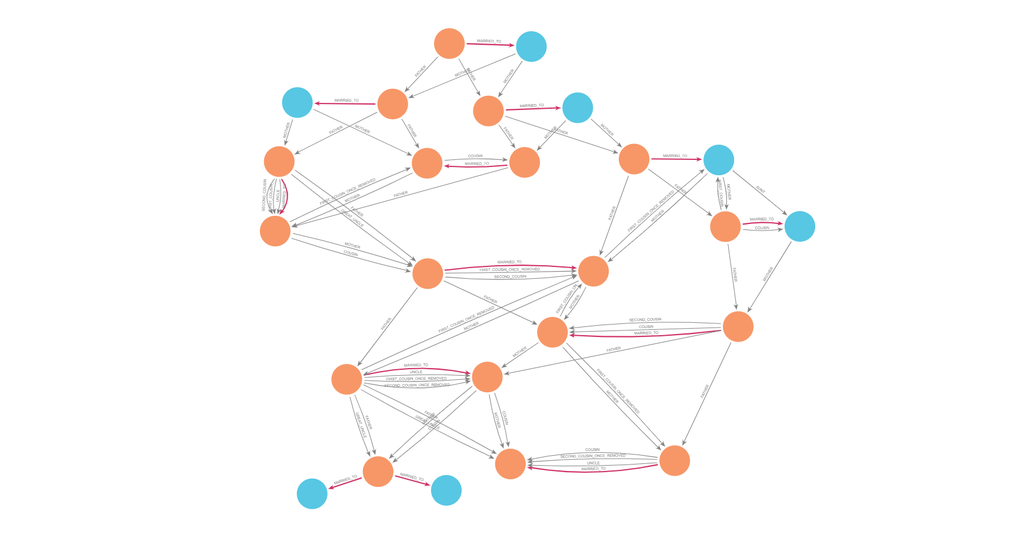

screenshot from Neo4j Bloom

[figure not shown]

Generated by Sora with a custom prompt.

Now let's make things a little simpler.  
First, let's define some functions: one to delete relationships, and one to rename them.

```python
def rename_relationship_type(tx, old_type, new_type, new_to_role_value):
    query = f"""
    MATCH (a)-[r:{old_type}]->(b)
    CALL (a, b, r) {{
      WITH a, b, r
      MERGE (a)-[new_r:{new_type}]->(b)
      SET new_r += properties(r)
      SET new_r.to_role = $new_to_role
      DELETE r
    }}
    RETURN COUNT(*) AS updated
    """
    result = tx.run(query, new_to_role=new_to_role_value)
    summary = result.single()
    print(f"Renamed {old_type} → {new_type}, updated: {summary['updated']} relationship(s).")
```

```python
def delete_relationship_type(tx, rel_type):
    query = f"""
    MATCH ()-[r:{rel_type}]->()
    DELETE r
    RETURN COUNT(r) AS deleted
    """
    result = tx.run(query)
    summary = result.single()
    print(f"Deleted {summary['deleted']} relationship(s) of type {rel_type}.")
```

Now let's rename "cousins" to "first cousins" and delete "second cousins once removed".

```python
with driver.session() as session:
    session.execute_write(
        rename_relationship_type,
        "COUSIN",
        "FIRST_COUSIN",
        "first cousin"
    )
    session.execute_write(delete_relationship_type,"SECOND_COUSIN_ONCE_REMOVED")
```

```
Renamed COUSIN → FIRST_COUSIN, updated: 7 relationship(s).
Deleted 2 relationship(s) of type SECOND_COUSIN_ONCE_REMOVED.
```

Let's just count both "first cousins once removed" and "second cousins" as "distant cousins".

```python
with driver.session() as session:
    session.execute_write(rename_relationship_type,
                          "FIRST_COUSIN_ONCE_REMOVED", "DISTANT_COUSIN", "distant cousin")
    session.execute_write(rename_relationship_type,
                          "SECOND_COUSIN", "DISTANT_COUSIN", "distant cousin")
```

```
Renamed FIRST_COUSIN_ONCE_REMOVED → DISTANT_COUSIN, updated: 9 relationship(s).
Renamed SECOND_COUSIN → DISTANT_COUSIN, updated: 3 relationship(s).
```

```python
with driver.session() as session:
    result = session.run("MATCH ()-[r:DISTANT_COUSIN]->() RETURN count(r) AS count")
    record = result.single()
    count = record["count"] if record else 0
    print(f"Number of DISTANT_COUSIN relationships: {count}")
```

```
Number of DISTANT_COUSIN relationships: 10
```

Now let’s say we’ve realized how dumb we were not to tag blood vs. marriage relationships back when we were parsing our data.  
Well, better late than never.

```python
def tag_marriage_relationships(tx):
    query = """
    MATCH ()-[r:MARRIED_TO]->()
    SET r.type = "by marriage"
    RETURN COUNT(r) AS updated
    """
    result = tx.run(query)
    print(f"Tagged {result.single()['updated']} relationships as 'by marriage'.")
```

```python
def tag_blood_relationships(tx):
    query = """
    MATCH ()-[r]->()
    WHERE type(r) <> "MARRIED_TO"
    SET r.type = "by blood"
    RETURN COUNT(r) AS updated
    """
    result = tx.run(query)
    print(f"Tagged {result.single()['updated']} relationships as 'by blood'.")
```

```python
with driver.session() as session:
    session.execute_write(tag_marriage_relationships)
    session.execute_write(tag_blood_relationships)
```

```
Tagged 13 relationships as 'by marriage'.
Tagged 58 relationships as 'by blood'.
```

Time to party query, y'all!

Who's that guy again, the son of Philip IV?

```python
with driver.session() as session:
    result = session.run("""
        MATCH (father:Person)
        WHERE father.name CONTAINS "Philip IV"
        MATCH (father)-[:FATHER]->(child:Person)
        WHERE child.gender = "M"
        RETURN child
        LIMIT 1
    """)
    record = result.single()
    if record:
        child_node = record["child"]
        print("Raw returned node object:", child_node)
        print("Node properties:", dict(child_node))
    else:
        print("No matching child found.")
```

```
Raw returned node object: <Node element_id='4:73115f1c-0399-48a2-8a03-8b2e4c96d2a1:23' labels=frozenset({'Person'}) properties={'gender': 'M', 'born': 1661, 'name': 'Charles II of Spain', 'died': 1700, 'house': 'Habsburg', 'person_id': 1}>
Node properties: {'gender': 'M', 'born': 1661, 'name': 'Charles II of Spain', 'died': 1700, 'house': 'Habsburg', 'person_id': 1}
```

Who's one of the most "connected"? *wink-wink*

```python
with driver.session() as session:
    query = """
    MATCH (p:Person)
    MATCH (p)-[r]-()
    WITH p, count(r) AS relCount
    ORDER BY relCount DESC
    LIMIT 1
    MATCH (p)-[r2]-(connected)
    RETURN p, collect({
      relationship: type(r2),
      node: connected,
      direction: CASE WHEN startNode(r2) = p THEN "outgoing" ELSE "incoming" END
    }) AS connections
    """
    result = session.run(query)
    record = result.single()
    if record:
        person = record["p"]
        connections = record["connections"]
        print(f"Person: {person['name']} (person_id: {person['person_id']})")
        print("Connections:")
        for c in connections:
            node = c['node']
            rel_type = c['relationship']
            direction = c['direction']
            arrow = "→" if direction == "outgoing" else "←"
            print(f" - {rel_type} {arrow} {node.get('name', 'Unknown')}")
    else:
        print("No person found.")
```

```
Person: Philip IV of Spain (person_id: 4)
Connections:
 - MARRIED_TO → Mariana of Austria
 - UNCLE → Mariana of Austria
 - FATHER → Margaret Theresa of Spain
 - FATHER → Charles II of Spain
 - FATHER ← Philip III of Spain
 - MOTHER ← Margaret of Austria
 - GREAT_UNCLE → Margaret Theresa of Spain
 - GREAT_UNCLE → Charles II of Spain
 - DISTANT_COUSIN → Mariana of Austria
 - DISTANT_COUSIN → Margaret of Austria
```

How is that "handsome" guy connected to our Charlie?

```python
with driver.session() as session:
    result = session.run(
        """
        MATCH (a:Person), (b:Person)
        WHERE a.name CONTAINS $nameA AND b.name CONTAINS $nameB
        MATCH path = shortestPath((a)-[*]-(b))
        RETURN path
        LIMIT 1
        """,
        nameA="Charles II of Spain",
        nameB="Handsome"
    )
    record = result.single()
    if not record:
        print(f"No path found between these persons.")
    else:
        path = record["path"]
        nodes = path.nodes
        relationships = path.relationships

        print(f"Shortest path between the two:")
        for i in range(len(nodes)):
            node = nodes[i]
            print(f"Node {i + 1}: {node['name']} (ID: {node['person_id']})")
            if i < len(relationships):
                rel = relationships[i]
                print(f"  --[{rel.type}]--")
```

```
Shortest path between the two:
Node 1: Charles II of Spain (ID: 1)
  --[FATHER]--
Node 2: Philip IV of Spain (ID: 4)
  --[FATHER]--
Node 3: Philip III of Spain (ID: 10)
  --[FATHER]--
Node 4: Philip II of Spain (ID: 12)
  --[FATHER]--
Node 5: Charles V, Holy Roman Emperor (ID: 18)
  --[FATHER]--
Node 6: Philip the Handsome (ID: 24)
```

And finally...

```python
with driver.session() as session:
    query = """
    MATCH (a)-[:MARRIED_TO]->(b)
    WITH DISTINCT a, b
    WITH collect({a: a, b: b}) AS marriedPairs, size(collect(DISTINCT [a,b])) AS total_married
    UNWIND marriedPairs AS pair
    WITH pair.a AS a, pair.b AS b, total_married
    WHERE EXISTS {
      MATCH (a)-[r]->(b)
      WHERE r.type = "by blood"
    } OR EXISTS {
      MATCH (b)-[r]->(a)
      WHERE r.type = "by blood"
    }
    RETURN
      total_married,
      count(*) AS also_blood_related,
      round(100.0 * count(*) / total_married, 2) AS percent_close_kin
    """
    result = session.run(query)
    stats = result.single()
    print(f"Total marriages: {stats['total_married']}")
    print(f"Intra-family marriages: {stats['also_blood_related']}")
    print(f"Genetic intimacy rate: {stats['percent_close_kin']}%")
```

```
Total marriages: 13
Intra-family marriages: 7
Genetic intimacy rate: 53.85%
```

P.S. Let's highlight *something* by creating new types of relationships based on the existing ones.

```python
def create_combined_relationship(tx, rel1, rel2, role_to_value):
    new_rel_type = f"{rel1}_AND_{rel2}"

    query = f"""
    MATCH (a)-[r1:{rel1}]->(b)
    MATCH (a)-[r2:{rel2}]->(b)
    WHERE NOT EXISTS {{
      MATCH (a)-[:{new_rel_type}]->(b)
    }}
    CREATE (a)-[new_r:{new_rel_type} {{role_to: $role_to}}]->(b)
    RETURN COUNT(*) AS created_count
    """

    result = tx.run(query, role_to=role_to_value)
    count = result.single()["created_count"]
    print(f"Created {count} '{new_rel_type}' relationships with role_to='{role_to_value}'.")
```

```python
with driver.session() as session:
    session.execute_write(create_combined_relationship, "UNCLE", "MARRIED_TO", "niece and married to")
    session.execute_write(create_combined_relationship, "MOTHER", "FIRST_COUSIN", "child and cousin")
```

```
Created 3 'UNCLE_AND_MARRIED_TO' relationships with role_to='niece and married to'.
Created 3 'MOTHER_AND_FIRST_COUSIN' relationships with role_to='child and cousin'.
```

Oh, isn't this the sweetest little group!

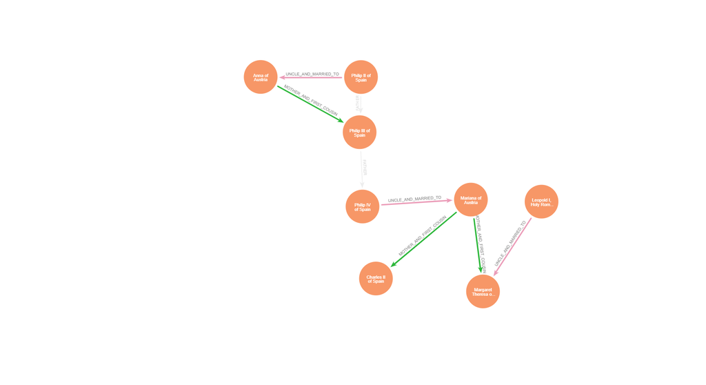

screenshot from Neo4j Bloom

Never forget to close the driver.

```python
driver.close()
```

[figure not shown]

The Graph Witch Luring the Developer Away from Tables  
Generated by Sora with a custom prompt.

**the end**